# Линейная алгебра. Практическая работа №9

[🌀 Home Page](https://olgabelitskaya.github.io/README.html) [📓 Previous](https://github.com/OlgaBelitskaya/linear_algebra_practice/blob/master/work1_8.ipynb) [📓 Next](https://github.com/OlgaBelitskaya/linear_algebra_practice/blob/master/work1_10.ipynb)

### Программные средства

[LaTeX. Mathematics](https://en.wikibooks.org/wiki/LaTeX/Mathematics)

[Sage. Linear Algebra](http://doc.sagemath.org/html/en/tutorial/tour_linalg.html)

[Numpy. Quickstart tutorial](https://docs.scipy.org/doc/numpy/user/quickstart.html#linear-algebra)

[R Functions - Tutorialspoint](https://www.tutorialspoint.com/r/r_functions.htm)

[Quick-R: User-Defined Functions](https://www.statmethods.net/management/userfunctions.html)

### Конспекты лекций

[АЛГЕБРА И ГЕОМЕТРИЯ ДЛЯ СТУДЕНТОВ-ФИЗИКОВ](http://math.phys.msu.ru/data/24/Algebra_and_geometry.pdf)

[Computational Mathematics with SageMath](http://dl.lateralis.org/public/sagebook/sagebook-ba6596d.pdf)

[Прямые и плоскости](http://hoster.bmstu.ru/~fn1/wp-content/uploads/2012/10/uchebno-metod/Surf_and_lines_ST_metod.pdf)

[Introduction to Symbolic Computation](http://homepages.math.uic.edu/~jan/mcs320/mcs320.pdf)

# Плоскости

## 1. Уравнения.

Общий вид

$\pi: \ a * x + b * y + c * z + d = 0$

$\overrightarrow{n}\{a;b;c\} \perp \pi$

Проходящая через точку $A_0(x_0;y_0;z_0)$ и перпендикулярная $\overrightarrow{n}\{a;b;c\}$

$\pi: \ a * (x - x_0) + b * (y - y_0) + c * (z -z_0) = 0$

Через три точки $A_1 (x_1;y_1;z_1), A_2 (x_2,y_2,z_2), A_3 (x_3,y_3,z_3)$

$\begin {vmatrix} x - x_1 & y - y_1 & z - z_1 \\ x_2 - x_1 & y_2 - y_1 & z_2 - z_1 \\ x_3 - x_1 & y_3 - y_1 & z_3 - z_1 \end{vmatrix} = 0$

В отрезках

$\pi: \frac{x}{\alpha} + \frac{x}{\beta} + \frac{z}{\gamma} = 1$

$\alpha = -\frac{d}{a}, \ \beta = -\frac{d}{b}, \ \gamma = -\frac{d}{c}$

Параметрические уравнения плоскости

$\pi: \begin {cases} x = x_0 + p_1 * t_1 + p_2 * t_2 \\ y = y_0 + q_1 * t_1 + q_2 * t_2 \\ z = z_0 + r_1 * t_1 + r_2 * t_2 \end {cases}, \ t_1, t_2 \in \mathbb{R}$

$\overrightarrow{s_1}\{p_1;q_1;r_1\}, \ \overrightarrow{s_2}\{p_2;q_2;r_2\} \parallel \pi, \ A_0(x_0;y_0;z_0) \in \pi$

Нормальное уравнение плоскости

$P$ - проекция начала координат $O(0;0;0)$ на плоскость $\pi$

$ |\overrightarrow{OP}| = p, \ \angle(\overrightarrow{OP}, \overrightarrow{OX}) = \alpha, \ \angle(\overrightarrow{OP}, \overrightarrow{OY}) = \beta, \ \angle(\overrightarrow{OP}, \overrightarrow{OZ}) = \gamma, \ $

$\pi: x \cdot \cos \alpha + y \cdot \cos \beta + z \cdot \cos \gamma = p$

$\cos^2 \alpha + \cos^2 \beta + \cos^2 \gamma = 1$

```python
var('x,y,z,x0,y0,z0,x1,y1,z1,x2,y2,z2,x3,y3,z3')
var('a,b,c,d,p1,q1,r1,p2,q2,r2,t1,t2')
eq=[a*x+b*y+c*z+d==0,
    a*(x-x0)+b*(y-y0)+c*(z-z0)==0,
    Matrix(SR,3,[x-x1,y-y1,z-z1,
                 x2-x1,y2-y1,z2-z1,
                 x3-x1,y3-y1,z3-z1]).det()==0,
    x==x0+p1*t1+p2*t2,
    y==y0+q1*t1+q2*t2,
    z==z0+r1*t1+r2*t2]
```

```python
solutions=[solve([eq[0],a==3,b==-1,c==-1,d==2],
                 a,b,c,d,x,y,z),
           solve([eq[1],a==3,b==2,c==-1,x0==1,y0==-1,z0==2],
                 a,b,c,d,x0,y0,z0,x,y,z),
           solve([eq[2],x1==-3,y1==2,z1==1,
                  x2==1,y2==-3,z2==3,x3==-2,y3==1,z3==1],
                 x1,y1,z1,x2,y2,z2,x3,y3,z3,x,y,z),
           solve([eq[3],eq[4],eq[5],x0==-1,y0==2,z0==-2,
                  p1==2,q1==1,r1==-1,p2==-2,q2==-3,r2==2],
                 x0,y0,z0,p1,q1,r1,p2,q2,r2,t1,t2,x,y,z)]
zsolutions=[solve([eq[0],a==3,b==-1,c==-1,d==2],a,b,c,d,z),
           solve([eq[1],a==3,b==2,c==-1,
                  x0==1,y0==-1,z0==2],a,b,c,d,x0,y0,z0,z),
           solve([eq[2],x1==-3,y1==2,z1==1,
                  x2==1,y2==-3,z2==3,x3==-2,y3==1,z3==1],
                 x1,y1,z1,x2,y2,z2,x3,y3,z3,z),
           solve([eq[3],eq[4],eq[5],x0==-1,y0==2,z0==-2,
                  p1==2,q1==1,r1==-1,p2==-2,q2==-3,r2==2],
                 x0,y0,z0,p1,q1,r1,p2,q2,r2,t1,t2,z)]
solutions[1],zsolutions[1]
```

```
([[a == 3, b == 2, c == -1, d == r3, x0 == 1, y0 == -1, z0 == 2, x == r4, y == r5, z == 3*r4 + 2*r5 + 1]],
 [[a == 3, b == 2, c == -1, d == r10, x0 == 1, y0 == -1, z0 == 2, z == 3*x + 2*y + 1]])
```

```python
var('x,y,z'); s=(-2,2)
f=[3*x-y-z+2,3*x+2*y-z+1,-2*x-2*y-z-1]
colors=['#3636ff','#ff3636','#36ff36']
text_xyz=[(2,2,2),(-2,2,2),(-2,-1,2)]
labels=['3x-y-z+2=0',
        '3x+2y-z+1=0',
        '-2x-2y-z-1=0']
p=sum([implicit_plot3d(f[i],s,s,s,
                       color=colors[i],
                       plot_points=10,
                       opacity=0.5,mesh=True)
       for i in [0..2]])
t=sum([text3d(labels[i],text_xyz[i],
              color=colors[i])
       for i in [0..2]])
(p+t).show()
```

[interactive chart not shown]

```python
import numpy,sympy,pylab,matplotlib,warnings
from mpl_toolkits.mplot3d import Axes3D
warnings.simplefilter("ignore",category=RuntimeWarning)
X=numpy.linspace(start=-10,stop=10,num=50)
X,Y=numpy.meshgrid(X,X)
def plane1(a,b,c,d,x,y): return -(a*x+b*y+d)/c
def plane2(a,b,c,x0,y0,z0,x,y):
    return -(a*(x-x0)+b*(y-y0))/c+z0
def plane3(x1,y1,z1,x2,y2,z2,x3,y3,z3,x,y):
    detX=(y2-y1)*(z3-z1)-(y3-y1)*(z2-z1)
    detY=(x2-x1)*(z3-z1)-(x3-x1)*(z2-z1)
    detZ=(x2-x1)*(y3-y1)-(x3-x1)*(y2-y1)
    return z1-((x-x1)*detX-(y-y1)*detY)/detZ
Z=[plane1(3,-1,-1,2,X,Y),
   plane2(3,2,-1,1,-1,2,X,Y),
   plane3(-3,2,1,1,-3,3,-2,1,1,X,Y)]
for z in Z:
    z[z<-10]=numpy.NaN; z[z>10]=numpy.NaN
x,y,z,x0,y0,z0,x1,y1,z1,x2,y2,z2,x3,y3,z3=\
sympy.symbols('x,y,z,x0,y0,z0,x1,y1,z1,x2,y2,z2,x3,y3,z3')
a,b,c,d,p1,q1,r1,p2,q2,r2,t1,t2=\
sympy.symbols('a,b,c,d,p1,q1,r1,p2,q2,r2,t1,t2')
eq=[a*x+b*y+c*z+d,
    a*(x-x0)+b*(y-y0)+c*(z-z0),
    sympy.Matrix([[x-x1,y-y1,z-z1],
                  [x2-x1,y2-y1,z2-z1],
                  [x3-x1,y3-y1,z3-z1]]).det(),
    x-x0-p1*t1-p2*t2,
    y-y0-q1*t1-q2*t2,
    z-z0-r1*t1-r2*t2]
```

```python
solutions=[sympy.solve([eq[0],a-3,b+1,c+1,d-2],a,b,c,d,z),
           sympy.solve([eq[1],a-3,b-2,c+1,x0-1,y0+1,z0-2],
                       a,b,c,x0,y0,z0,z),
           sympy.solve([eq[2],x1+3,y1-2,z1-1,
                        x2-1,y2+3,z2-3,x3+2,y3-1,z3-1],
                       x1,y1,z1,x2,y2,z2,x3,y3,z3,z),
           sympy.solve([eq[3],eq[4],eq[5],x0+1,y0-2,z0+2,
                        p1-2,q1-1,r1+1,p2+2,q2+3,r2-2],
                       x0,y0,z0,p1,q1,r1,p2,q2,r2,x,y,z)]
for s in solutions: sympy.pprint(s); print('\n')
```

```
[(3, -1, -1, 2, 3⋅x - y + 2)]


[(3, 2, -1, 1, -1, 2, 3⋅x + 2⋅y + 1)]


[(-3, 2, 1, 1, -3, 3, -2, 1, 1, -2⋅x - 2⋅y - 1)]


{p₁: 2, p₂: -2, q₁: 1, q₂: -3, r₁: -1, r₂: 2, x: 2⋅t₁ - 2⋅t₂ - 1, x₀: -1, y: t
₁ - 3⋅t₂ + 2, y₀: 2, z: -t₁ + 2⋅t₂ - 2, z₀: -2}
```

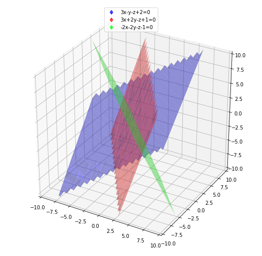

```python
f=pylab.figure(figsize=(9,9))
ax=f.add_subplot(111,projection='3d')
colors=['#3636ff','#ff3636','#36ff36']
labels=['3x-y-z+2=0','3x+2y-z+1=0','-2x-2y-z-1=0']
for i in range(3):
    ax.plot_surface(X,Y,Z[i],color=colors[i],alpha=0.5)
fake2Dlines=[matplotlib.lines.Line2D([0],[0],linestyle="none",
                                     c=colors[i],marker='d')
             for i in range(3)]
ax.set_xlim(-10,10); ax.set_ylim(-10,10); ax.set_zlim(-10,10)
ax.legend(fake2Dlines,labels,loc=9); pylab.show()
```

```python
%%r
X<-Y<-seq(from=-10,to=11,by=1)
plane1<-function(a,b,c,d,x,y){-(a*x+b*y+d)/c}
plane2<-function(a,b,c,x0,y0,z0,x,y){-(a*(x-x0)+b*(y-y0))/c+z0}
plane3<-function(x1,y1,z1,x2,y2,z2,x3,y3,z3,x,y){
    detX<-(y2-y1)*(z3-z1)-(y3-y1)*(z2-z1)
    detY<-(x2-x1)*(z3-z1)-(x3-x1)*(z2-z1)
    detZ<-(x2-x1)*(y3-y1)-(x3-x1)*(y2-y1)
    z1-((x-x1)*detX-(y-y1)*detY)/detZ}
Z1<-plane1(3,-1,-1,2,X,Y)
Z2<-plane2(3,2,-1,1,-1,2,X,Y)
Z3<-plane3(-3,2,1,1,-3,3,-2,1,1,X,Y)
library(grDevices); library(Matrix)
```

```
[1] "Matrix"    "tools"     "stats"     "graphics"  "grDevices" "utils"
[7] "datasets"  "methods"   "base"
```

```python
%%r
svg(filename="Rplots.svg",width=7,height=7,pointsize=12,
    onefile=TRUE,family="sans",bg="white",
    antialias=c("default","none","gray","subpixel"))
cols<-c('#3636ff','#ff3636','#36ff36')
labs<-c('3x-y-z+2=0','3x+2y-z+1=0','-2x-2y-z-1=0')
plot(X,Z1,col=cols[1],type='l',lwd=3,
     xlim=c(-10,10),ylim=c(-10,10),xlab='x',ylab='z')
lines(X,Z2,col=cols[2],lwd=3)
lines(X,Z3,col=cols[3],lwd=3)
legend(4,-4,title='XOZ: y=0',labs,col=cols,lwd=3)
grid(); dev.off()
```